# COPRED twitter dummy

## Introducción

Se realiza un análisis exploratorio de los tweets de los últimos 7 días por motivo de discriminación y un análisis de texto de los mismos.

### Género

#### Mini EDA

- Dimensión

```
[1] 1229   18
```

| tipo | n |
| --- | --- |
| como_nina | 375 |
| es_de_nina | 351 |
| como_hombre | 253 |
| discriminacion_mujeres | 67 |
| feminazi | 65 |
| vieja_loca | 43 |
| mama_luchona | 35 |
| vieja_pendeja | 28 |
| tienes_hijos | 12 |

#### TF_IDF

- TF_IDF con dos palabras

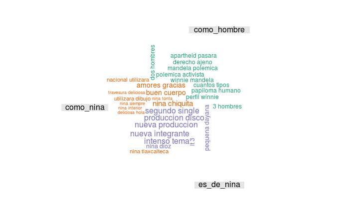

- TF_IDF con tres palabras

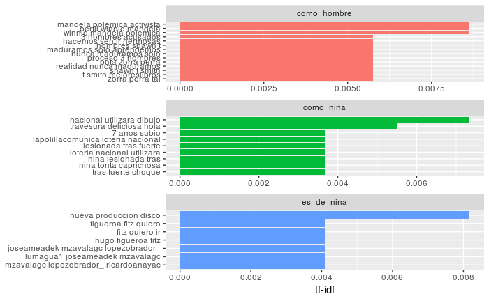

[figure not shown]

#### Correlación de palabras

##### Completas

[output not shown]

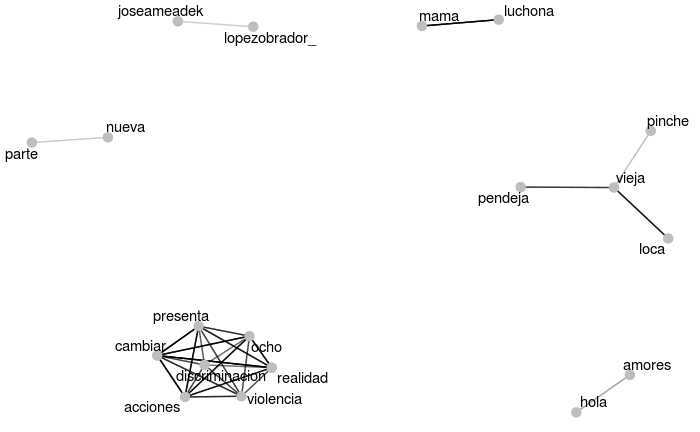

### Orientación/Identidad sexual

#### Mini EDA

- Dimensión

```
[1] 761  18
```

- Dentro del motivo de discriminacios Orientación/Identidad sexual se cuentan con 8 adjetivos.

| tipo | n |
| --- | --- |
| pinche_puto | 259 |
| lesbiana | 199 |
| joto | 196 |
| punial | 51 |
| lencha | 25 |
| pinche_maricon | 21 |
| arroz_popote | 6 |
| pinche_lesbiana | 4 |

#### TF_IDF

- TF_IDF con dos palabras

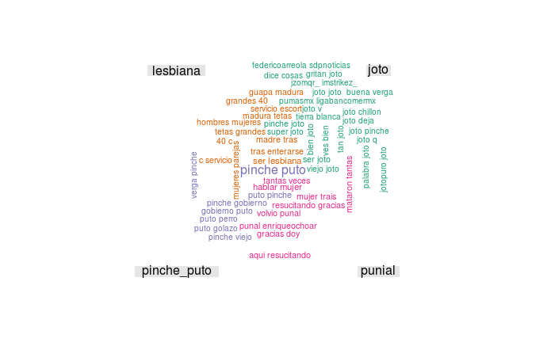

- TF_IDF con tres palabras

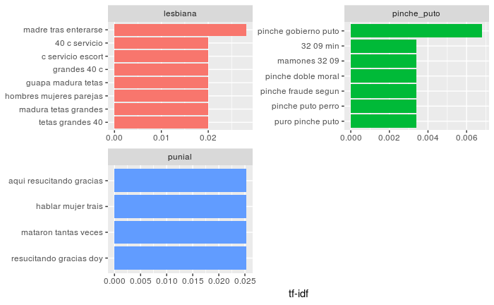

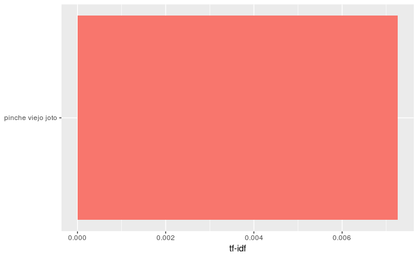

#### Correlación de palabras

##### Completas

[output not shown]

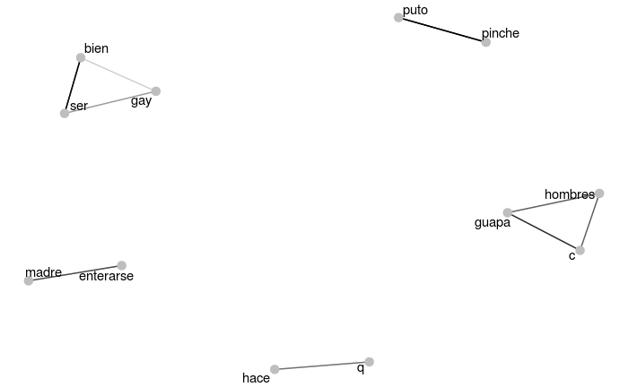

### Ideoligía política

#### Mini EDA

- Dimensión

```
[1] 931  18
```

- Dentro del motivo de discriminacios Ideoligía política se cuentan con 3 adjetivos.

| tipo | n |
| --- | --- |
| chairo | 826 |
| feminazi | 66 |
| derechairo | 39 |

#### TF_IDF

- TF_IDF con dos palabras

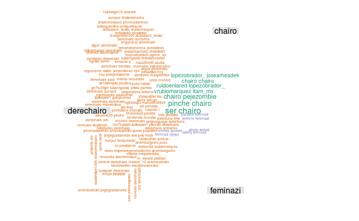

- TF_IDF con tres palabras

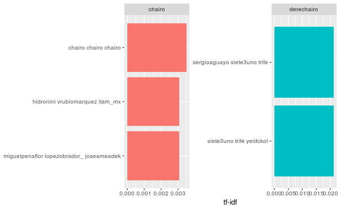

#### Correlación de palabras

##### Completas

[output not shown]

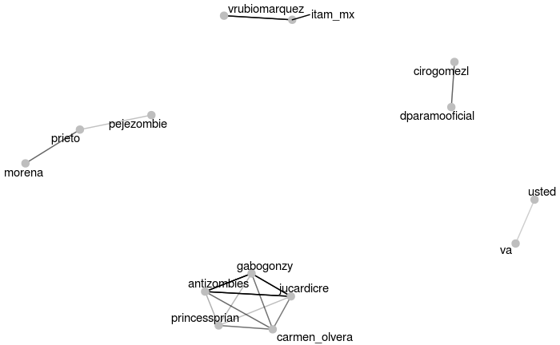

### Apariencia

#### Mini EDA

- Dimensión

```
[1] 1659   18
```

- Dentro del motivo de discriminacios apariencia se cuentan con 10 adjetivos.

| tipo | n |
| --- | --- |
| naco | 856 |
| jodido | 459 |
| pinche_gordo | 135 |
| pinche_pobre | 68 |
| chacha | 66 |
| pinche_negro | 24 |
| guerito | 19 |
| pinche_indio | 16 |
| iztapalacra | 8 |
| pinche_fresa | 8 |

#### TF_IDF

- TF_IDF con dos palabras

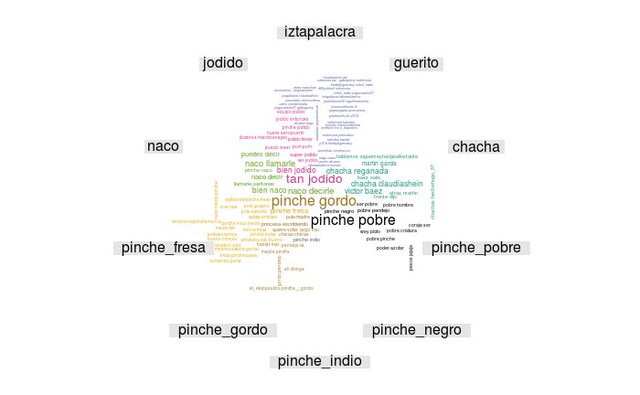

- TF_IDF con tres palabras

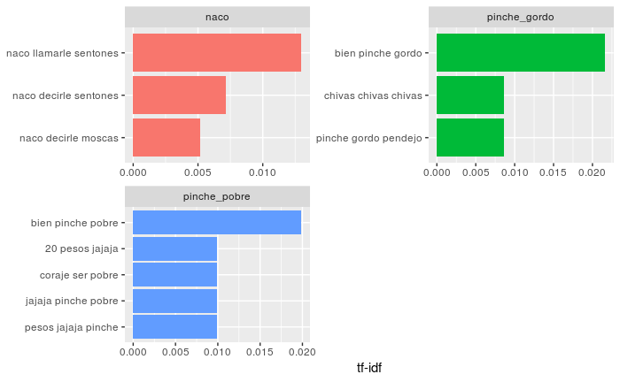

#### Correlación de palabras

##### Completas

[output not shown]

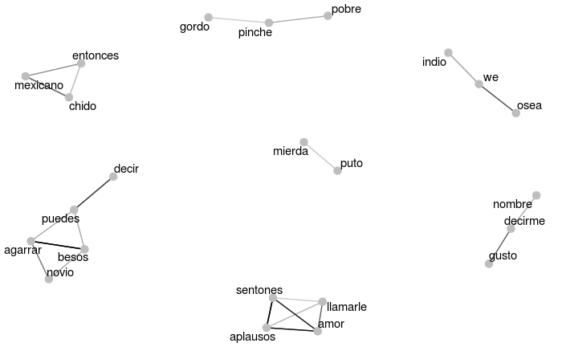

### Religión

#### Mini EDA

- Dimensión

```
[1] 57 18
```

- Dentro del motivo de discriminacios religion se cuentan con 4 adjetivos.

| tipo | n |
| --- | --- |
| testigos_jehova | 51 |
| testiculos_jehova | 3 |
| pinche_judio | 2 |
| religioso_pendejo | 1 |

#### TF_IDF

- TF_IDF con dos palabras

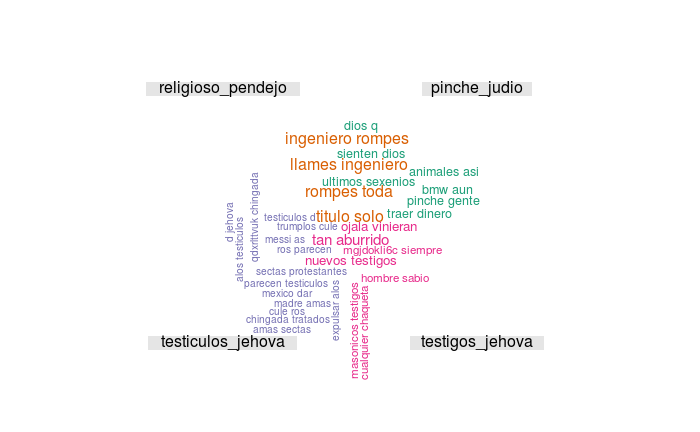

- TF_IDF con tres palabras

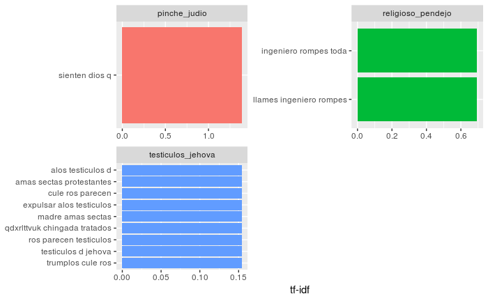

#### Correlación de palabras

##### Completas

[output not shown]

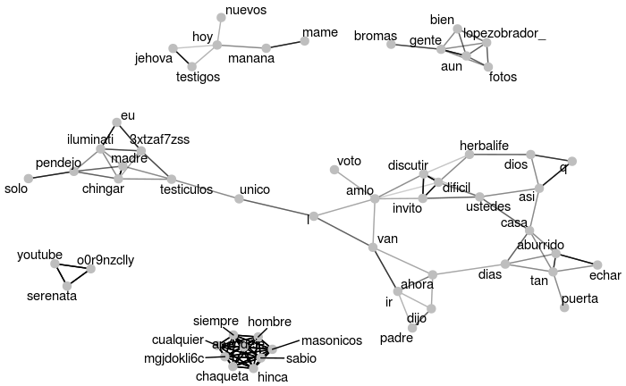

### Edad

#### Mini EDA

- Dimensión

```
[1] 675  18
```

- Dentro del motivo de discriminacios edad se cuentan con 6 adjetivos.

| tipo | n |
| --- | --- |
| es_chavo | 199 |
| nini | 177 |
| pinche_viejo | 146 |
| chavoruco | 108 |
| pinche_ninio | 41 |
| pareces_nino_chiquito | 4 |

#### TF_IDF

- TF_IDF con dos palabras

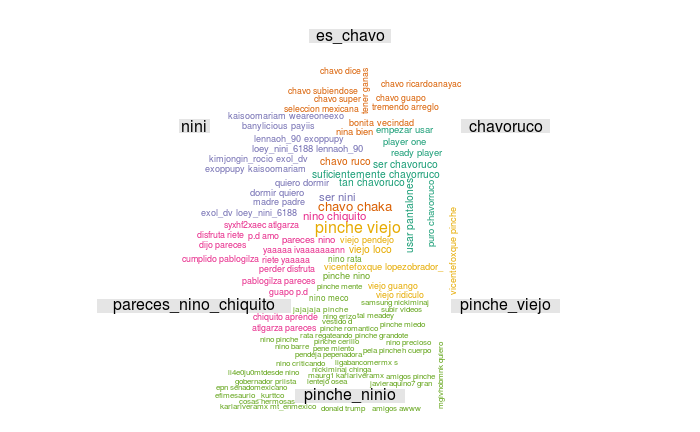

- TF_IDF con tres palabras

[figure not shown]

#### Correlación de palabras

##### Completas

[output not shown]

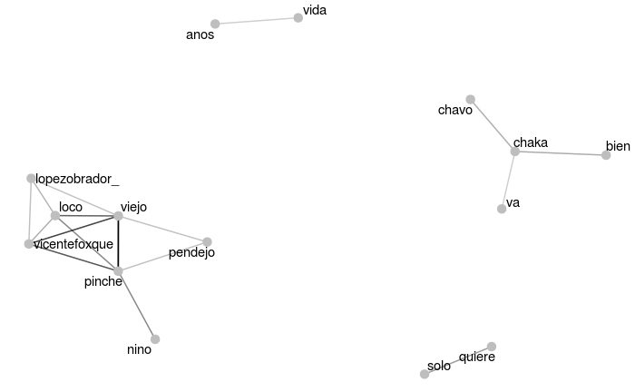

### Discapacidad

#### Mini EDA

- Dimensión

```
[1] 742  18
```

- Dentro del motivo de discriminacios discapacidad se cuentan con 3 adjetivos.

| tipo | n |
| --- | --- |
| ciego | 420 |
| cojo | 248 |
| discapacitado | 74 |

#### TF_IDF

- TF_IDF con dos palabras

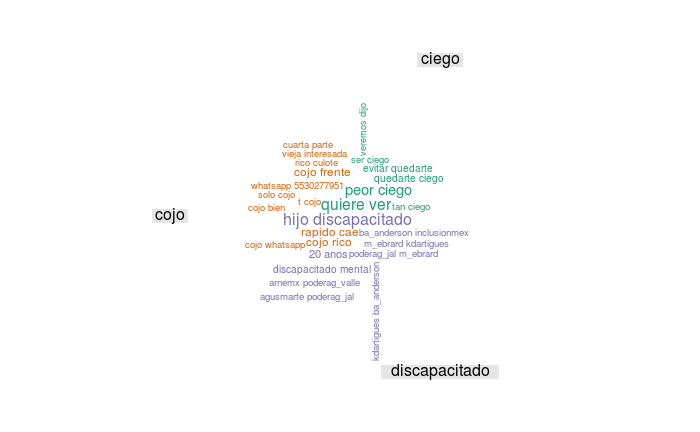

- TF_IDF con tres palabras

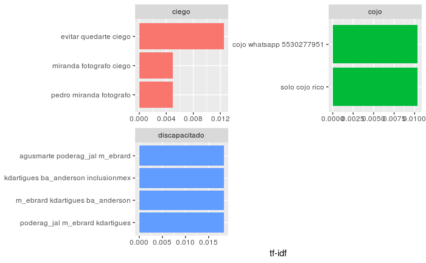

#### Correlación de palabras

##### Completas

[output not shown]

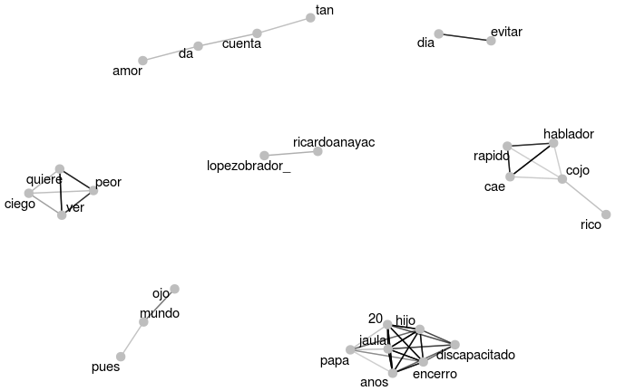